# FigureYa80GOclustering

小丫画图出品

2019-3-10

欢迎关注“小丫画图”公众号，同名知识星球等你加入

小丫微信: epigenomics E-mail: figureya@126.com

作者：小丫

## 需求描述

富集分析得到太多GO term，其中好多还是相似的，怎样合理的合并？clusterProfiler有一个simplify函数，能给富集分析结果瘦身by removing redundancy of enriched GO terms，但有时瘦的不够多。小丫找到这样一篇例文，它列出了富集的 term，同时在旁边给出一个短语来概括性的描述这几个相似的term：

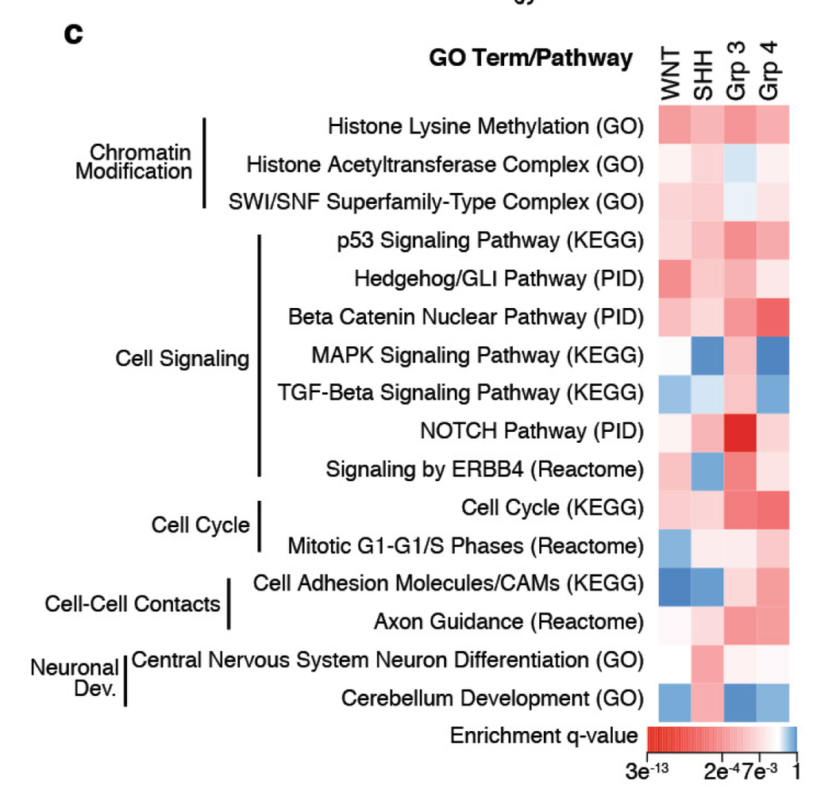

出自https://www.nature.com/articles/nature22973

**方法探讨：**

Extended Data Figure 5 | Candidate driver genes and pathways in MB subgroups. c, GO and pathway summary of recurrently mutated genes in MB. GO and pathway categories are **grouped according to functional theme** and the proportion of cases affected by individual pathway alterations are plotted per subgroup and across the series.

例文中关于这些相似term如何合并的描述只说grouped according to functional theme。因此，我用Y叔的GOSemSim计算GO term之间的相似性，然后借助ggtree实现例文中相似GO germ的标注效果。关于ggtree和GOSemSim的问题，请前往Y叔知识星球biobabble讨论。

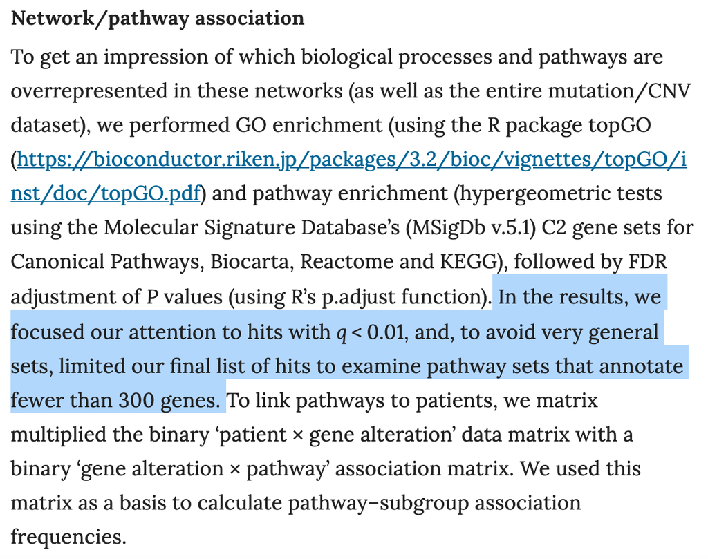

## 应用场景

多组GO富集分析结果放在一起对比；

富集分析得到太多相似的GO term，需要合并相似的，再结合背景知识概括出合适的pathway。

## 环境设置

使用国内镜像安装包

```r
options("repos"= c(CRAN="https://mirrors.tuna.tsinghua.edu.cn/CRAN/"))
options(BioC_mirror="http://mirrors.ustc.edu.cn/bioc/")

if (!requireNamespace("BiocManager", quietly = TRUE))
    install.packages("BiocManager")
BiocManager::install("GOSemSim", version = "3.8")
BiocManager::install("ggtree", version = "3.8")
```

加载包

```r
library(plyr)
library(stringr)
library(ape)
library(GOSemSim)
```

```r
library(ggplot2)
library(ggtree)
library(scales)
library(cowplot)
Sys.setenv(LANGUAGE = "en") #显示英文报错信息
options(stringsAsFactors = FALSE) #禁止chr转成factor
```

## 输入文件

富集分析结果至少包含GO term ID（格式为GO:0046777）和一列统计量（例如pvalue、p.ajdust、FDR等等）。

此处用clusterProfier的enrichGO函数做的富集分析结果为例(FigureYa52GOplot的输出文件enrichGO_output.csv)，其中有一列BgRatio，斜线左侧是全基因组范围内该term里基因的数量。例文以300为阈值，去掉了基因数量超过300的term。如果你的数据没有这一列，也可以不做这一步筛选。

```r
#多组富集分析结果的文件名统一命名，便于导入
fnames <- Sys.glob("enrichGO*.csv")
fnames
```

```
## [1] "enrichGO1.csv" "enrichGO2.csv" "enrichGO3.csv"
```

```r
#读取ID、Description、BgRatio、p.adjust四列
fdataset <- lapply(fnames, function(x){read.csv(x)[,c(2,3,5,7)]})
names(fdataset) <- fnames
```

## 纵向合并多组富集结果，用于给GO term分类

```r
ego.all <- ldply(fdataset, data.frame)
ego.all$group <- unlist(strsplit(ego.all$.id, split = ".csv"))
head(ego.all)
```

```
##             .id         ID
## 1 enrichGO1.csv GO:0046777
## 2 enrichGO1.csv GO:0034329
## 3 enrichGO1.csv GO:0034330
## 4 enrichGO1.csv GO:0048638
## 5 enrichGO1.csv GO:0098742
## 6 enrichGO1.csv GO:0061564
##                                                 Description   BgRatio
## 1                               protein autophosphorylation 235/23239
## 2                                    cell junction assembly 200/23239
## 3                                cell junction organization 248/23239
## 4                        regulation of developmental growth 392/23239
## 5 cell-cell adhesion via plasma-membrane adhesion molecules 199/23239
## 6                                          axon development 483/23239
##       p.adjust     group
## 1 2.289313e-05 enrichGO1
## 2 2.289313e-05 enrichGO1
## 3 2.514272e-05 enrichGO1
## 4 2.862196e-05 enrichGO1
## 5 7.325205e-05 enrichGO1
## 6 7.325205e-05 enrichGO1
```

```r
dim(ego.all)
```

```
## [1] 379   6
```

```r
#用p.ajust<0.001来筛
ego.all <- ego.all[ego.all$p.adjust < 0.001,]
dim(ego.all)
```

```
## [1] 67  6
```

```r
# GO term的合集
ego.ID <- unique(ego.all[,c(2:4)])
head(ego.ID)
```

```
##           ID                                               Description
## 1 GO:0046777                               protein autophosphorylation
## 2 GO:0034329                                    cell junction assembly
## 3 GO:0034330                                cell junction organization
## 4 GO:0048638                        regulation of developmental growth
## 5 GO:0098742 cell-cell adhesion via plasma-membrane adhesion molecules
## 6 GO:0061564                                          axon development
##     BgRatio
## 1 235/23239
## 2 200/23239
## 3 248/23239
## 4 392/23239
## 5 199/23239
## 6 483/23239
```

```r
dim(ego.ID)
```

```
## [1] 42  3
```

```r
##GO term筛选
#删掉超过300个基因的GO term
#如果不想删除，可以注释掉下面这段
ego.ID$Bg <- as.numeric(str_split_fixed(ego.ID$BgRatio, "/",2)[,1]) #提取GO term包含的基因数量
ego.ID <- ego.ID[ego.ID$Bg < 300,]
dim(ego.ID)
```

```
## [1] 28  4
```

```r
#删掉少于100个基因的GO term
#具体怎样筛选，要根据你自己的数据灵活设置
ego.ID <- ego.ID[ego.ID$Bg > 100,]
dim(ego.ID)
```

```
## [1] 17  4
```

```r
head(ego.ID)
```

```
##            ID                                               Description
## 1  GO:0046777                               protein autophosphorylation
## 2  GO:0034329                                    cell junction assembly
## 3  GO:0034330                                cell junction organization
## 5  GO:0098742 cell-cell adhesion via plasma-membrane adhesion molecules
## 11 GO:0034332                            adherens junction organization
## 12 GO:0043405                         regulation of MAP kinase activity
##      BgRatio  Bg
## 1  235/23239 235
## 2  200/23239 200
## 3  248/23239 248
## 5  199/23239 199
## 11 121/23239 121
## 12 293/23239 293
```

## 横向合并多组富集结果，用于画热图

MyMerge函数出自：https://stackoverflow.com/questions/16666643/merging-more-than-2-dataframes-in-r-by-rownames

```r
MyMerge <- function(x, y){
  df <- merge(x, y, by= "ID", all.x= TRUE, all.y= TRUE)
  return(df)
}
ego.m <- Reduce(MyMerge, fdataset)
head(ego.m)
```

```
##           ID                 Description.x BgRatio.x  p.adjust.x
## 1 GO:0001101     response to acid chemical 360/23239 0.002930340
## 2 GO:0001569                          <NA>      <NA>          NA
## 3 GO:0001654               eye development 388/23239 0.004062686
## 4 GO:0001667 ameboidal-type cell migration 403/23239 0.004966390
## 5 GO:0001771                          <NA>      <NA>          NA
## 6 GO:0001821                          <NA>      <NA>          NA
##                   Description.y BgRatio.y  p.adjust.y
## 1     response to acid chemical 360/23239 0.001468792
## 2                          <NA>      <NA>          NA
## 3                          <NA>      <NA>          NA
## 4 ameboidal-type cell migration 403/23239 0.006608313
## 5                          <NA>      <NA>          NA
## 6                          <NA>      <NA>          NA
##                                        Description   BgRatio     p.adjust
## 1                        response to acid chemical 360/23239 0.0006815207
## 2 branching involved in blood vessel morphogenesis  43/23239 0.0038990772
## 3                                             <NA>      <NA>           NA
## 4                                             <NA>      <NA>           NA
## 5                  immunological synapse formation  14/23239 0.0098705602
## 6                              histamine secretion  16/23239 0.0118921025
```

```r
#只保留GO term ID和各组的p.adjust
ego.m <- ego.m[,c(1,4,7,10)] #此处有三组，如果有更多组，要在后面继续加
#提取筛选过的GO term
ego.m <- merge(ego.ID[,1:2], ego.m, by= "ID", all.x= TRUE)
rownames(ego.m) <- ego.m$Description
ego.m$ID <- NULL
ego.m$Description <- NULL

#把列名改为组名
#colnames(ego.m)<- str_remove(fnames, ".csv")
colnames(ego.m) <- paste0("G", seq(1:length(fnames)))

#用全部GO term做富集分析，多组合并后会有缺失值
#解决方案是DIY富集分析，过后会众筹，敬请关注小丫画图群内消息
#不推荐的做法是用1补，或者换成其他你认为合理的数值
#ego.m[is.na(ego.m)] <- 1
head(ego.m)
```

```
##                                                   G1           G2           G3
## hexose transmembrane transport          7.192349e-03 7.182741e-04           NA
## phosphatidylinositol 3-kinase signaling 3.034455e-03 1.056311e-03 4.681760e-04
## monosaccharide transmembrane transport  2.641971e-03 7.233140e-04           NA
## leukocyte chemotaxis                    3.250458e-04 6.114471e-03 3.191574e-03
## carbohydrate transmembrane transport    2.641971e-03 7.278261e-04           NA
## cell junction assembly                  2.289313e-05 5.226172e-08 7.619747e-09
```

## 按GO term的相似性聚类

```r
# 人
#hgGO <- godata('org.Hs.eg.db', ont="BP")
#save(hgGO, file="hgGO.rdata")
#(load("hgGO.rdata"))

# 小鼠
#这一步需要运行1min，可以把它保存到mmGO.rdata文件，便于重复使用
#mmGO <- godata('org.Mm.eg.db', ont="BP") ##或MF或CC，要跟你富集分析时的参数一致
#save(mmGO, file="mmGO.rdata")
(load("mmGO.rdata")) #导入之前保存的文件
```

```
## [1] "mmGO"
```

```r
#计算GO term之间的相似性
ego.sim <- mgoSim(ego.ID$ID, ego.ID$ID, semData=mmGO, measure="Wang", combine=NULL)
ego.sim[1:3, 1:3]
```

```
##            GO:0046777 GO:0034329 GO:0034330
## GO:0046777      1.000      0.096      0.122
## GO:0034329      0.096      1.000      0.799
## GO:0034330      0.122      0.799      1.000
```

```r
#用GO term作为行名、列名，便于查看和画图
rownames(ego.sim) <- ego.ID$Description
colnames(ego.sim) <- ego.ID$Description
ego.sim[1:3, 1:3]
```

```
##                             protein autophosphorylation cell junction assembly
## protein autophosphorylation                       1.000                  0.096
## cell junction assembly                            0.096                  1.000
## cell junction organization                        0.122                  0.799
##                             cell junction organization
## protein autophosphorylation                      0.122
## cell junction assembly                           0.799
## cell junction organization                       1.000
```

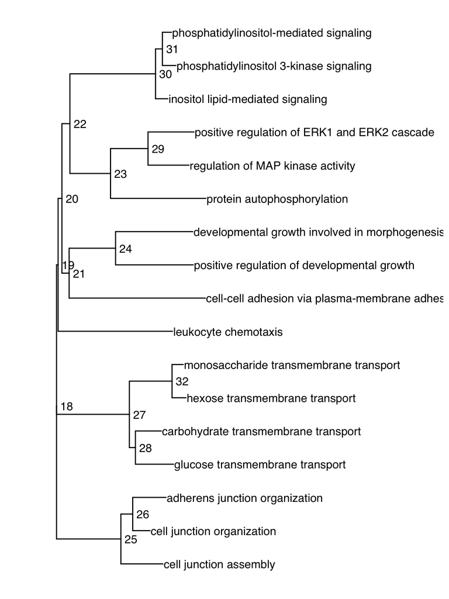

```r
#给GO term分类
tree <- nj(as.dist(1-ego.sim))
p <- ggtree(tree) + geom_tiplab() + #写GO term
  geom_text2(aes(subset=!isTip, label=node), hjust=-.3) + #写node编号
  coord_cartesian(xlim=c(-.1,1.3)) #左右两侧留出合适的空间
p
```

## 开始画图

**注：**根据实际情况，调整offset的值

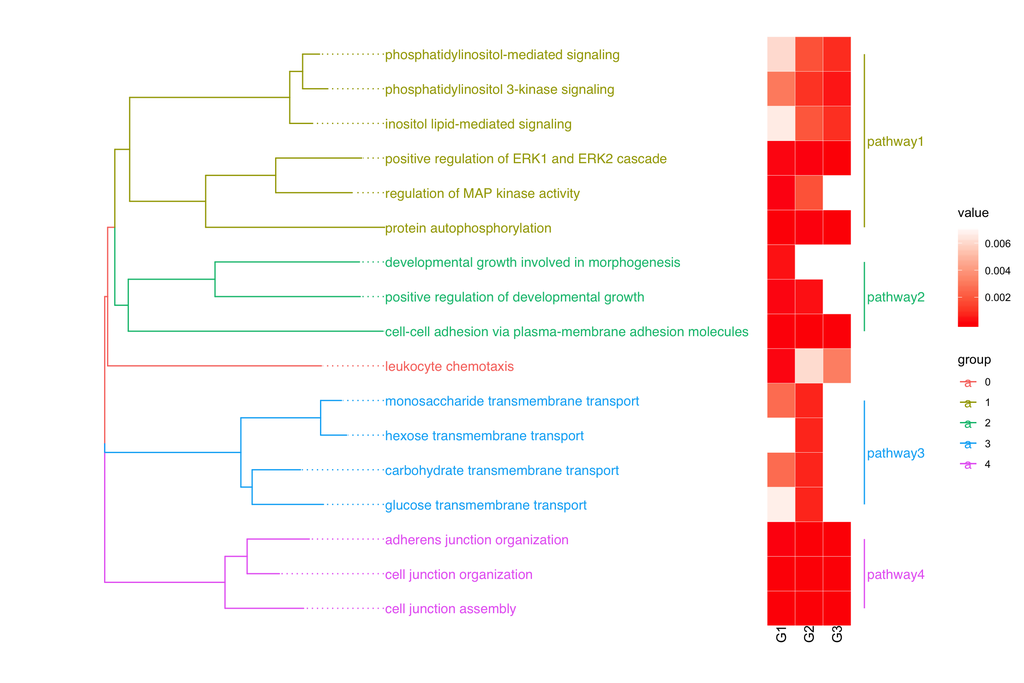

```r
#结合树的结构和背景知识，此处把GO term分为4类，记下每一类的node编号，写在node参数里
node <- c(22,21,27,25)
gtree <- groupClade(tree, .node=node)
#用不同颜色展示不同类GO term
pbase <- ggtree(gtree,
                aes(color=group)) #每类用不同颜色画树枝

#给4类term分别总结出一个短语，作为分类名，标在树的旁边
fontsize <- 4 #字的大小
offset <- .9 #分类名向右移动到热图右侧，也可以设为0.3，让它显示在热图跟树之间
pnode <- pbase +
  #如果不想显示每个GO term，就不运行这行，同时offset <- 0
  geom_tiplab(size=4, align=TRUE) + #GO germ对齐
  geom_cladelabel(node=node[1], align=TRUE,
                  #文字颜色跟树枝颜色一致，也可以删掉下面这行，就会像例文那样全是黑色
                  color = hue_pal()(length(node)+1)[2],
                  fontsize = fontsize, offset=offset, label="pathway1") +
  geom_cladelabel(node=node[2], align=TRUE, color = hue_pal()(length(node)+1)[3], fontsize = fontsize, offset=offset, label="pathway2") +
  geom_cladelabel(node=node[3], align=TRUE, color = hue_pal()(length(node)+1)[4], fontsize = fontsize, offset=offset, label="pathway3") +
  geom_cladelabel(node=node[4], align=TRUE, color = hue_pal()(length(node)+1)[5], fontsize = fontsize, offset=offset, label="pathway4") +
  #如果有更多分类，就继续往下粘贴

  coord_cartesian(xlim=c(-.1,1.5))
# 把p.ajust画在树形结构右侧
gheatmap(pnode, ego.m,
         offset=.7, #热图向右移动到合适的位置
         width=0.3, #heatmap格子的宽度
         colnames_angle=90, hjust=0, #组的名字竖着写
         low = "red", high = "white")
```

```r
#保存到文件
ggsave("GOclustering.pdf", width = 12, height = 8)
```

最后生成的pdf文件是矢量图，可以在Illustrator或Inkscape中打开、编辑。

可以参考例文的布局，手动删掉树形结构或调整各部分的位置。